# GEOG 176A: Intro to GIS

Lab 03: Distances and the Border Zone

[Ian Hinds](https://hindstein.github.io/GEOG176A/)

## Libraries

```r
# SPDS
library(tidyverse)
library(sf)
library(units)

# Data
library(USAboundaries)
library(rnaturalearthdata)

# Visualization
library(gghighlight)
library(ggrepel)
library(knitr)
```

## Background

In this lab, 4 main skills are covered:

- 1. **Ingesting/Building** *sf* objects from R packages and CSVs. (Q1)
- 2. **Manipulating** geometries and coordinate systems (Q2)
- 3. **Calculaing** distances (Q2)
- 4. **Building** maps using ggplot (Q3)

## Question 1:

For this lab, 3 datasets are needed.

- 1. Spatial boundaries of continental USA states (1.1)
- 2. Boundaries of Canada, Mexico, and the United States (1.2)
- 3. All USA cities (1.3)

### **1.1 Define a Projection**

For this lab we want to calculate distances between features, therefore we need a projection that perserves distance at the scale of CONUS. For this, we will use the North American Equidistant Conic:

```r
eqdc = '+proj=eqdc +lat_0=40 +lon_0=96 +lat_1=20 +lat_2=60 +x_0=0 +y_0=0 +datum=NAD83 +units=m +no_defs'
```

Unfortunately this projection does not have a EPSG code to reference so we must use the PROJ4 string above. Take a moment and describe this projection based on the parameters: **The PROJ4 string transforms geodetic coordinates to other projections.**

### **1.2 - Get USA state boundaries**

In R, USA boundaries are stored in the *USAboundaries* and *USAboundariesData* packages.

Once installed:

```r
conus = USAboundaries::us_states() %>%
  filter(!state_name %in% c("Puerto Rico",
                            "Alaska",
                            "Hawaii"))
```

### **1.3 - Get country boundaries for Mexico, the United States of America, and Canada**

In R, country boundaries are stored in the *rnaturalearth* package.

Once Installed:

- World boundaries can be accessed with **rnaturalearth::countries110**.
- The data is in simple features (**sf**) format.
- The countries used will be The United States, Mexico, and Canada
- The data is in a projected coordinate system suitable for distance measurements at the national scale (*eqdc*)

```r
countries = rnaturalearthdata::countries110 %>%
st_as_sf() %>%
  st_transform(eqdc) %>%
  filter(admin %in% c("United States", "Mexico", "Canada"))
```

### **1.4 - Get city locations from the CSV file**

The process of finding, downloading and accesing data is the first step of every analysis.

Once *uscities.csv* is downloaded, it is read into this working session using **read_csv**. Then, the data.frame is converted to a spatial object using **st_as_sf** and includes coordinate variables and a CRS.

```r
uscities <- read_csv("../data/uscities.csv")
View(uscities)
```

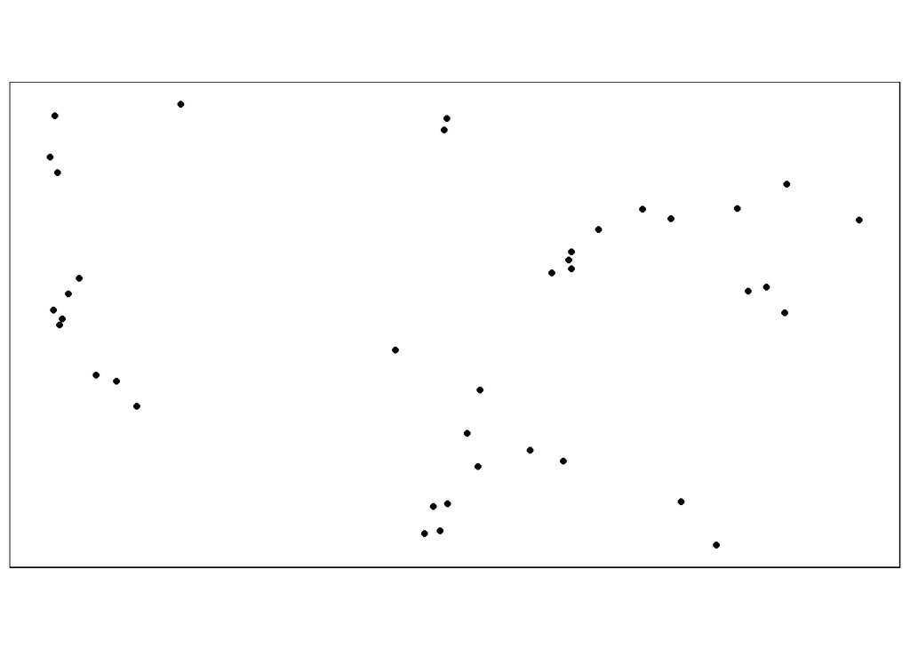

```r
uscities %>%
 st_as_sf(coords = c("lng", "lat"), crs = 4326) %>%
  filter(state_id %in% c("WA", "OR", "CA", "TX", "LA", "FL", "VA", "DC", "MA", "NY", "MI", "IL", "WI", "ND", "MT")) %>%
  filter(city %in% c("Seattle", "Portland", "Sacramento", "San Jose", "San Francisco", "Santa Cruz", "Santa Barbara", "Los Angeles", "San Diego", "Houston", "New Orleans","Tampa","Miami", "Washington", "Baltimore", "Philadelphia", "New York City", "Boston", "Buffalo","Detroit","Chicago", "Milawaukee", "Kalispell")) %>%
  ggplot() +
  geom_sf() +
  coord_sf (datum = st_crs()) +
  theme_linedraw()
```

## Question 2:

Here we will focus on calculating the distance of each USA city to (1) the national border (2) the nearest state border (3) the Mexican border and (4) the Canadian border. Existing spatial geometries will be manipulated using **st_union** or **st_combine** depending on the situation. In all cases, since we are after distances to borders, we will need to cast (**st_cast**) our *MULTIPOLYGON* geometries to *MULTILINESTRING* geometries. To perform these distance calculations we will use **st_distance()**.

```r
comb_multi = st_combine(conus) %>%
  st_cast("MULTILINESTRING")

farcities = USAboundaries::us_cities() %>%
  st_as_sf(coords = c("lng", "lat"), crs = 4326)
```

```
## City populations for contemporary data come from the 2010 census.
```

## Question 3:

Next, focus on visualizing distance data from above. Use **ggplo**t to make maps, **ggrepl** to label significant features, and **gghighlight** to emphasize imortant criteria.

### **3.1 Data**

- Use **geom_sf** to plot layers
- Use **lty** to change line type and size to change width
- Use **ggrepel::geom_label_repel** to label your cities

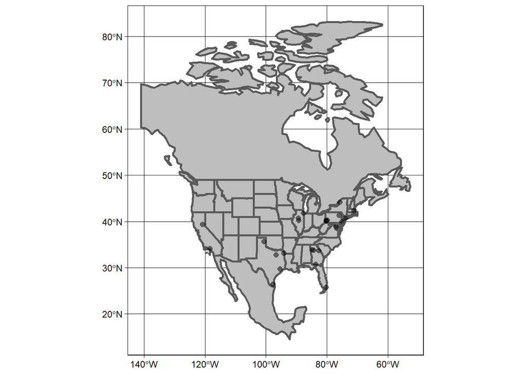

```r
large <- read_csv("../data/uscities.csv") %>%
  st_as_sf(coords = c("lng", "lat"), crs = 4326) %>%
  filter(city %in% c("New York", "Los Angeles", "Chicago", "Miami", "Dallas", "Philadelphia", "Houston", "Washington", "Atlanta", "Boston")) %>%
  filter(state_id %in% c("NY", "CA", "IL", "FL", "TX", "PA", "TX", "DC", "GA", "MA"))


ggplot() +
  geom_sf(data = conus, fill = 'gray', size = 1) +
  geom_sf(data = countries, fill = 'gray', size = 1) +
  geom_sf(data = large, fill = 'red', size = 2, alpha = .5) +
  theme_linedraw()
```

## Quesiton 4:

### Real World Application

Federal Agencies have claimed that constitutional rights protected by the 4th Amendment(protecting Americans from random and arbitrary stops and searches) do not apply fully at our borders. For example, FAs do not need a warrant or suspicion of wrongdoing o justify conducting what courts have called a “routine search”, such as searching luggage or a vehicle. SPecifically, federal regulations give U.S. Customs and Border Protection (CBP) authority to operate within 100 miles of any U.S. “external boundary”. Further info can be found at this [ACLU article.](https://www.aclu.org/other/constitution-100-mile-border-zone)

### **4.1 Quantifing Border Zone**

- How many cities are in this 00 mile zone?
- How many people live in a city within 100 miles of this border?
- What percentage of the total population is in this zone?
- Does it match the ACLU estimate in the link above?